# 2014-2018: Weekly vs Monthly

Pritam Dalal

March 10, 2019

This is the first in a series of analyses where I dig into 12 ETFs which have weekly options, monthly options, and CBOE published volatility index.

The weekly expiration included are 1/10/2014 - 12/28/2018. The monthly expirations included are 1/18/2014 - 12/21/2018.

We consider selling 10, 30, 50 delta strangles (variation), both delta-hedged and non-delta hedged.

In this analysis, we are trying to answer the following question: *Is it better to sell weekly or monthly options?*

In all my previous research, the evidence points to weekly options outperforming monthly options, so I am viewing these results through this lense.

### Underlying/Variation Combinations Indiviudally

In this section we consider underlying/variation cominations individually, and check to see how often the sharpe ratio of the weekly strategy is greater than the sharpe ratio of the analogous monthly strategy.

This is a perfectly reasonable framework, but there is one small problem: comparing two strategies by sharpe ratio is only meaningful if both of the sharpes are positive, i.e. if both of the strategies had positive returns. In our analysis, some of the underlying/variation/tenor combinations have negative returns, and hence a negative sharpe, so we can’t use sharpe to rank all strategies.

There are two work around to this:

1. Limiting the analysis to underlying/variation combinations where both tenors have a positive sharpe ratio.
2. Using the rank-sharpe ratio to compare the tenors.

#### Restricting to Meaningful Cases

One work around I tried is restricting myself only those underlying/variation combinations that had meaningful sharpes for both weekly and monthly.

**Delta-Hedge**

```
## [1] "Count both positive (delta-hedge): 21"
```

```
## [1] "Count weekly is better (delta-hedge): 17"
```

```
## [1] "Portion for which weekly better (delta-hedge): 0.81"
```

The delta-hedge percentage is 80%, which seems reasonable.

**Naked**

```
## [1] "Count both positive (naked): 15"
```

```
## [1] "Count weekly is better (naked): 6"
```

```
## [1] "Portion for which weekly better (naked): 0.4"
```

The naked percentage of 40% seems a bit low, but I’m not too concerned.

#### Compare with Rank-Sharpe

Another work around that I came up with is the concept of a rank-Sharpe, which is calculated by taking the rank of the avg-pnl and dividing by the rank of the stdev-pnl. This worked well, and gave the expected results.

For both naked and delta-hedge there are 36 underlying/variation combinations: 3 delta-variations and 12 underlyings.

**Delta-Hedge**

```
## [1] "weekly better than monthly (delta-hedge): 30 of 36."
```

```
## [1] "Percent (delta-hedge): 0.83"
```

The delta-hedge percentage of 83% looks as expected.

**Naked:**

```
## [1] "weekly better than monthly (naked): 33 of 36."
```

```
## [1] "Percent (naked): 0.92"
```

The naked percentage of 92% looks as googd also.

### Sharpe Ratio All Underlyings Combined

In this section we aggregate all the underlyings together for each tenor/delta-variation combination, and then calculate the sharpe ratios for the weekly and monthly strategies.

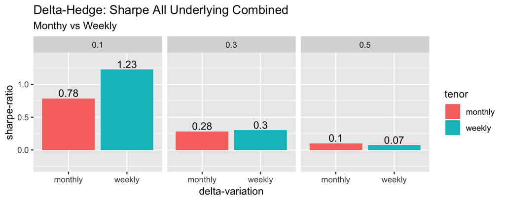

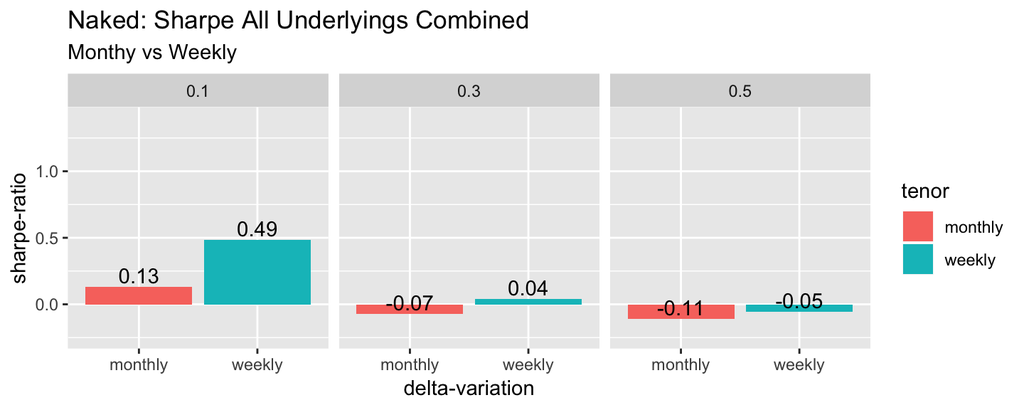

### Appendix - Underlyings Individually

In this appendix, we graph the sharpes for all the underlyings individually.

#### Delta Hedge

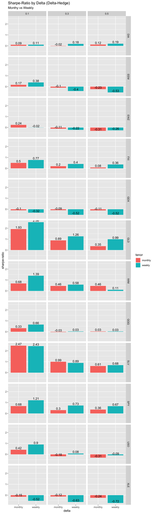

#### Naked

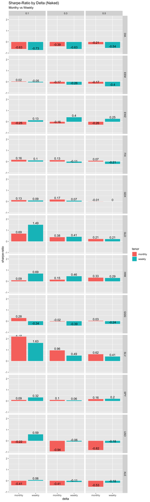